# Malaria Data Science

Assigment - Week 2

PETER ABUGRI

08 February, 2025

[figure not shown]

## Instructions

Solve the exercises below by providing the R code inside the code chunks, and the plain English answers outside (and below) the code chunks. Submit both the RMarkdown (.Rmd) file and the resulting HTML file. Data are provided in the `data` sub-folder.

## Data

A randomized clinical trial was conducted to test the efficacy of a new drug on the prevention of malaria for people travelling (visiting) to regions with high malaria transmission. The study took place in a remote village in Mozambique, in which adult visitors planning to stay for at least two months were asked to participate in the trial. The participants were enrolled within 24 hours of arrival, and randomly assigned to the receive the study drug or placebo (fake drug).

The inclusion (eligibility) criteria:

- Having 18 or more years of age
- Not having malaria infection (confirmed by negative PCR test)
- No being pregnant

The trial was blinded, i.e., participant did not know if they were taking the active drug or placebo. The trial was blinded, i.e., participant did not know if they were taking the active drug or placebo. Data were collect at two time points, at enrolment and at end of follow-up period of 2 months.

The data collected at enrolment are provided in the file `recruitment_data.csv` and contains the following variables:

- `subject_id`: the unique participant identifier assigned at enrolment
- `date_enrol`: the date of participant enrolment, format: YYYY-MM-DD
- `date_birth`: participant’s birth date, format: YYYY-MM-DD
- `sex`: participant’s sex, coded 1 (Female) and 2 (Male)
- `weight_kg`: participant’s weight in kilograms
- `height_cm`: participate height in centimetres
- `malaria_origin`: malaria transmission at the place of participant’s origin, coded 0 (no transmission), 1 (low transmission), 2 (moderate transmission), and 3 (high transmission)
- `treatment`: the treatment group assigned to the participant, coded 0 (placebo) and 1 (active drug)

The data collected at the end of follow-up is in the `end_data.csv`, with the following variables:

- `subject_id`: the unique participant identifier assigned at enrolment
- `date_end`: date of the end of follow-up visit, format: YYYY-MM-DD
- `malaria_epi`: total number of malaria episodes the participant had from the enrolment till end of follow-up
- `bednet`: use of bed net by the participant during the study period, coded 0 (never), 1(sometimes) and 2 (always)

The data files are located in the `data/orig` subfolder.

The two data files where pre-processed in R to create a single final dataset for analysis, and saved to the file `merged_data.rds` in the `data/proc` subfolder.` During the pre-processing, new variables were created, namely:

- `age_y`: age in years at enrolment
- `height_m`: height in metres at enrolment
- `bmi`: body mass index at enrolment
- `had_malaria`: whether a participant had malaria during the study follow-up period (Yes/No)

The body mass index (BMI) is a measure of body fat based on height and weight, and is calculated as
$$\text{BMI}
= \frac{\text{w}}{\text{h}^2}$$
where $w$ is weight in kilograms and $h$ is height in metres.

## Exercises

### Exercise 1

Import the final (merged) dataset into your R session, assigning to an R object named `mds`. Then print the structure of the `mds` data frame.

Are the variables data types in line with their description above?

#### Exercise 1 Solution:

```r
# Write your code inside this code chunk
#getwd()

mds<-readRDS("/home/guest/Desktop/Malaria Data Science/AssigmentWeek2/data/proc/merged_data.rds")
# number of columns
ncol(mds)
```

```
TRUE [1] 15
```

```r
# names of variables
names(mds)
```

```
TRUE  [1] "subject_id"     "date_enrol"     "date_birth"     "sex"
TRUE  [5] "weight_kg"      "height_cm"      "malaria_origin" "treatment"
TRUE  [9] "age_y"          "height_m"       "bmi"            "date_end"
TRUE [13] "malaria_epi"    "bednet"         "had_malaria"
```

```r
# Data structure using the base r and the glimse function

str(mds)
```

```
TRUE 'data.frame':  1000 obs. of  15 variables:
TRUE  $ subject_id    : chr  "P0001" "P0002" "P0003" "P0004" ...
TRUE  $ date_enrol    : Date, format: "2022-10-02" "2022-10-02" ...
TRUE  $ date_birth    : Date, format: "1987-02-02" "1987-03-06" ...
TRUE  $ sex           : Factor w/ 2 levels "Female","Male": 1 2 1 2 1 2 2 1 2 2 ...
TRUE  $ weight_kg     : num  46.6 83.2 72.2 58 62.5 67.8 61.4 52.2 53.4 53.5 ...
TRUE  $ height_cm     : int  151 147 149 150 150 149 149 150 148 149 ...
TRUE  $ malaria_origin: Factor w/ 4 levels "No","Low","Moderate",..: 3 2 4 4 1 4 4 3 1 1 ...
TRUE  $ treatment     : Factor w/ 2 levels "Placebo","Active": 2 1 1 1 2 1 1 1 1 2 ...
TRUE  $ age_y         : num  35.7 35.6 35.8 35.6 35.5 ...
TRUE  $ height_m      : num  1.51 1.47 1.49 1.5 1.5 1.49 1.49 1.5 1.48 1.49 ...
TRUE  $ bmi           : num  20.4 38.5 32.5 25.8 27.8 ...
TRUE  $ date_end      : Date, format: "2022-11-30" "2022-12-01" ...
TRUE  $ malaria_epi   : int  0 0 1 1 1 1 0 0 2 1 ...
TRUE  $ bednet        : Factor w/ 3 levels "Never","Sometimes",..: 3 2 3 1 1 2 1 2 2 2 ...
TRUE  $ had_malaria   : Factor w/ 2 levels "Yes","No": 2 2 1 1 1 1 2 2 1 1 ...
```

```r
#glimpse(mds)
```

# Are the variables data types in line with their description above?

Yes, the variable data types align with their descriptions above. However, I noticed changes in some of the labels for malaria_origin, bednet, treatment etc.

For example, malaria_origin maintains the same data type as defined previously, but the levels now range from 1 to 4 instead of 0 to 3.” bednet now range 1 to 3 instead of 0 to 2, treatment now range 1 to 2 instead of 0 to 1 etc.

### Exercise 2

One thing that can affect or distort the comparison of the two treatment groups (placebo vs active drug) with regard to the outcome of interest (having malaria during the study follow-up period) is the imbalance of the participant characteristics between the two treatment groups. Construct a table containing summary statistics of participant characteristics by treatment group. The characteristics to consider are: sex, body mass index, malaria transmission at the place of origin, age, and use of bed net. Include also the p-values from the appropriate statistical tests to check whether there are significant differences (of participant characteristics) between the two groups.

Checking your output table, are there significant differences? If yes, in what characteristics?

#### Exercise 2 Solution:

```r
# Define independent and dependent variables
v_indep <- c("sex", "bmi", "malaria_origin", "age_y", "bednet")
v_dep <- "treatment"

# Generate summary table with specific options for continuous and categorical variables
mds |>
  summary_factorlist(v_dep, v_indep, p=TRUE, p_cont_para = 't.test',
                     p_cat = 'chisq', add_dependent_label=FALSE,
                     cont = "mean", total_col = FALSE,
                     add_col_totals = TRUE, add_row_totals = TRUE,
                     na_include = TRUE, na_to_p = FALSE,
                     na_to_prop = FALSE,
                     include_col_totals_percent = FALSE) -> summary_table

# Display the table using kable and apply styling
summary_table |>
  kable(caption = "Summary Statistics and P-values by Treatment Group") |>
  kable_styling(bootstrap_options = c("striped", "hover"), full_width = F, font_size = 12) |>
  kable_classic(full_width = FALSE)
```

Summary Statistics and P-values by Treatment Group

| label | Total N | Missing N | levels | Placebo | Active | p |
| --- | --- | --- | --- | --- | --- | --- |
| Total N |  |  |  | 485 | 515 |  |
| sex | 1000 (100.0) | 0 | Female | 259 (53.4) | 258 (50.1) | 0.326 |
|  |  |  | Male | 226 (46.6) | 257 (49.9) |  |
|  |  |  | (Missing) | 0 | 0 |  |
| bmi | 1000 (100.0) | 0 | Mean (SD) | 26.8 (4.7) | 26.6 (4.5) | 0.518 |
| malaria_origin | 1000 (100.0) | 0 | No | 118 (24.3) | 131 (25.4) | 0.334 |
|  |  |  | Low | 120 (24.7) | 118 (22.9) |  |
|  |  |  | Moderate | 130 (26.8) | 120 (23.3) |  |
|  |  |  | High | 117 (24.1) | 146 (28.3) |  |
|  |  |  | (Missing) | 0 | 0 |  |
| age_y | 1000 (100.0) | 0 | Mean (SD) | 35.9 (0.4) | 35.9 (0.4) | 0.075 |
| bednet | 1000 (100.0) | 0 | Never | 166 (34.2) | 159 (30.9) | 0.442 |
|  |  |  | Sometimes | 154 (31.8) | 180 (35.0) |  |
|  |  |  | Always | 165 (34.0) | 176 (34.2) |  |
|  |  |  | (Missing) | 0 | 0 |  |

### Interpretation of Results

#### Not really

- **Sex**:
  - **Distribution**: 53.4% female in Placebo vs. 50.1% female in Active.
  - **P-value**: 0.326 - indicating **no significant difference** in sex distribution between the treatment groups.
- **BMI (Body Mass Index)**:
  - **Means**: 26.8 (SD 4.7) in Placebo vs. 26.6 (SD 4.5) in Active.
  - **P-value**: 0.518 - suggesting **no significant difference** in BMI across both treatment categories.
- **Malaria Origin**:
  - **Distribution varies** across No, Low, Moderate, and High categories.
  - **P-value**: 0.334 - showing **no significant difference** in malaria transmission origin.
- **Age (age_y)**:
  - **Means**: Approximately 35.9 years with a similar SD in both groups.
  - **P-value**: 0.075 - a trend towards significance but **not statistically significant**.
- **Bednet Usage**:
  - **Distribution**: Across Never, Sometimes, Always.
  - **P-value**: 0.442 - indicating **no significant difference** in bednet usage.

### Conclusion

The analysis revealed that there are **no statistically significant differences** in the examined characteristics between the Placebo and Active treatment groups at the standard significance level of 0.05 base on t-test on the continuous variables and Chi test on the categorical variables. This suggests that the groups are well balanced, and differences in treatment outcomes can reliably be attributed to the treatment effects rather than baseline characteristics.

### Exercise 3

We are interested in comparing, visually, the distribution of the body mass index between the two treatment groups. Use a box plot to achieve this goal.

What are your conclusions? Are there any outliers?

#### Exercise 3 Solution:

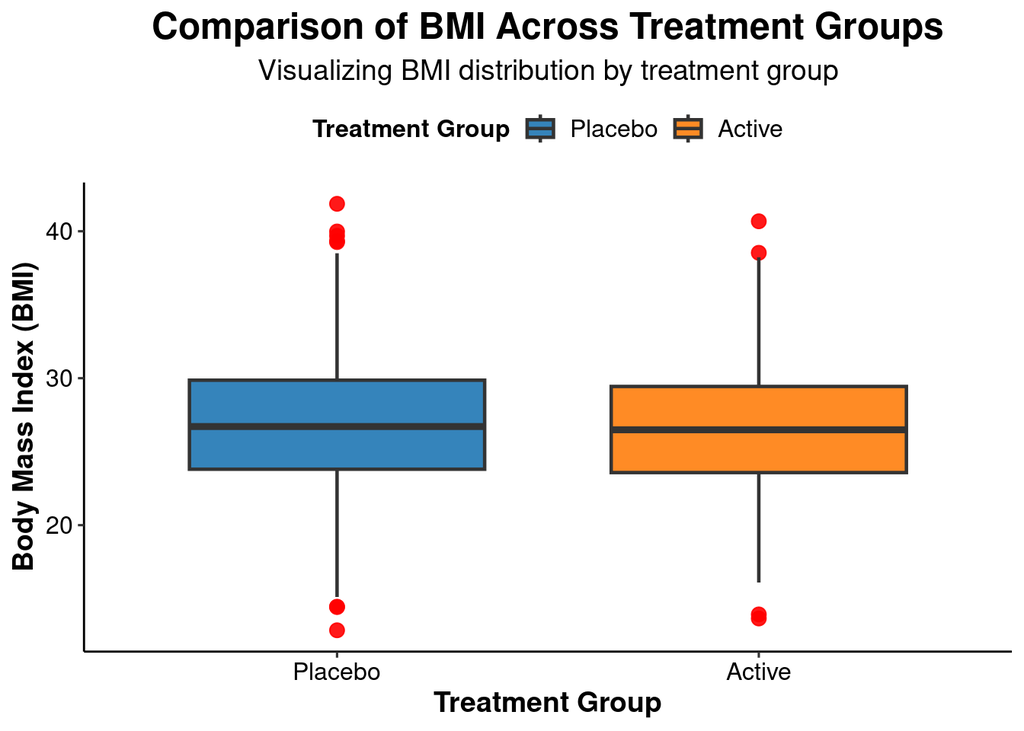

```r
# Custom color palette
custom_colors <- c("#1f77b4", "#ff7f0e", "#2ca02c", "#d62728", "#9467bd")

# Adding this to my  plot
ggplot(mds, aes(x = treatment, y = bmi, fill = treatment)) +
  geom_boxplot(
    outlier.color = "red",
    outlier.size = 3,
    size = 0.8,
    width = 0.7,
    alpha = 0.9
  ) +
  labs(
    title = "Comparison of BMI Across Treatment Groups",
    subtitle = "Visualizing BMI distribution by treatment group",
    x = "Treatment Group",
    y = "Body Mass Index (BMI)",
    fill = "Treatment Group"
  ) +
  theme_pubr() +
  theme(
    plot.title = element_text(size = 18, face = "bold", hjust = 0.5),
    plot.subtitle = element_text(size = 14, hjust = 0.5),
    axis.title.x = element_text(size = 14, face = "bold"),
    axis.title.y = element_text(size = 14, face = "bold"),
    axis.text.x = element_text(size = 12),
    axis.text.y = element_text(size = 12),
    legend.title = element_text(size = 12, face = "bold"),
    legend.text = element_text(size = 12)
  ) +
  scale_fill_manual(values = custom_colors)  # Use custom colors
```

Conclusion

Equivalence of Groups: The box plot analysis indicates no appreciable difference in the BMI distributions between the Placebo and Active treatment groups. This equivalence suggests that BMI, a potential confounding variable, is uniformly distributed across both groups, supporting the integrity of the randomization process.

# Observations of Outliers

The analysis of the BMI distributions for both the Placebo and Active treatment groups shows the presence of outliers, which are significant as they indicate BMIs that deviate notably from the rest of the data. Below are the specific findings for each group:

### Placebo Group

- **Observations**: A number of outliers are present above the upper quartile range.

### Active Group

- **Observations**: Several outliers are similarly noted above the upper quartile in the Active group.

### Exercise 4

The main objective of the study was to evaluate the efficacy of the new drug (active drug) in preventing malaria infection. That is, we hypothesize that the new drug reduces the probability of getting malaria infection, compared to placebo. Some participant characteristics might be malaria risk factors (i.e., associated with malaria). It is, therefore, important to check for this associations before performing the confirmatory analysis.

Check for possible associations between the participant characteristics and the outcome (`had_malaria`). The characteristics to check are: `sex`, `bmi`, `age`, and `bednet`. Present in form of table, similar to that of the Exercise 2. Include also the p-values.

What insights are getting from your output?

#### Exercise 4 Solution:

## Before running the possible association of these variables, I first of all looked at the possible test either parametric or non parametric test for the Continous variables `bmi` and `age`.

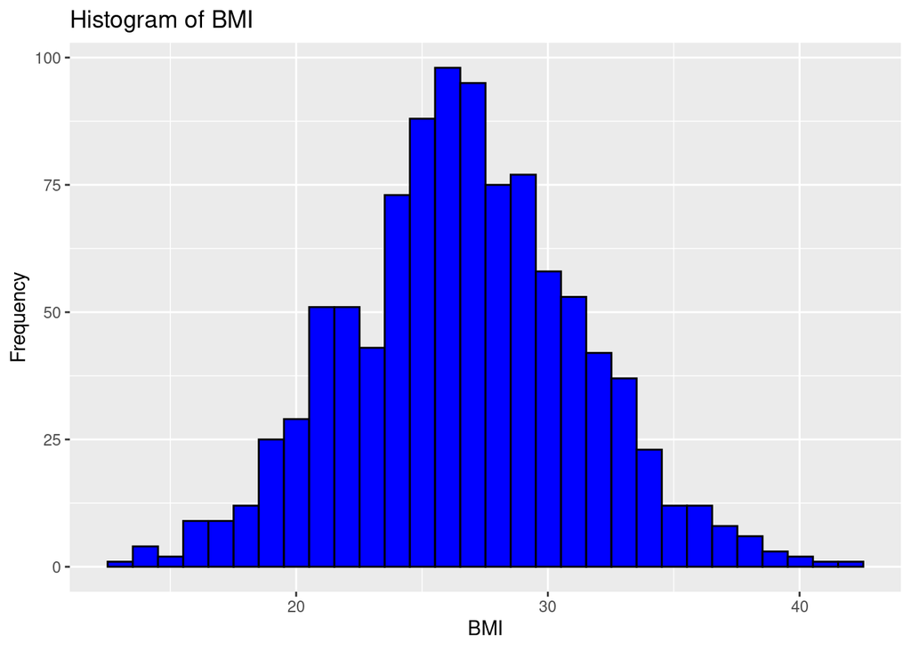

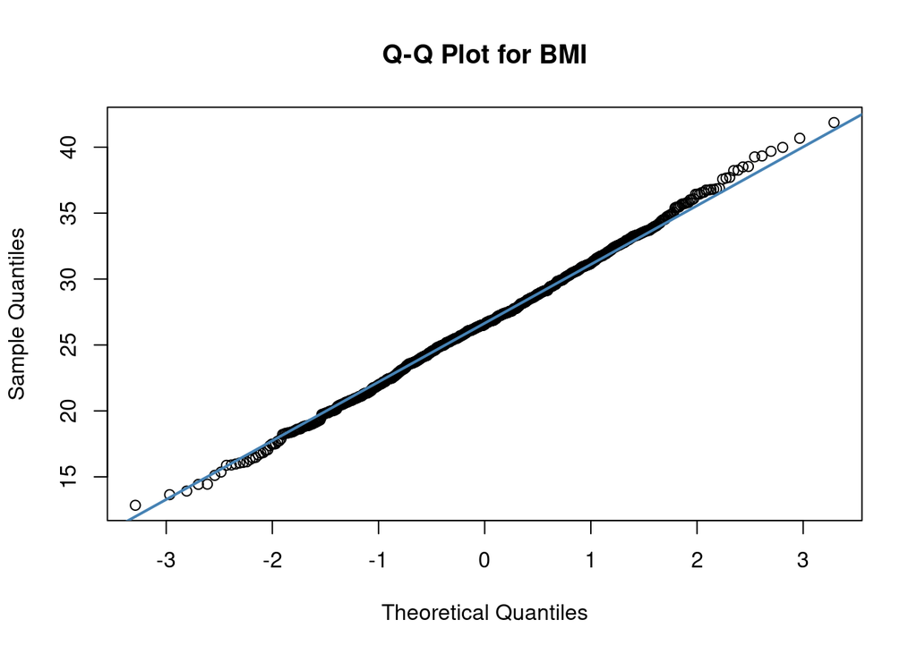

```
TRUE
TRUE    Shapiro-Wilk normality test
TRUE
TRUE data:  mds$bmi
TRUE W = 0.99877, p-value = 0.7368
```

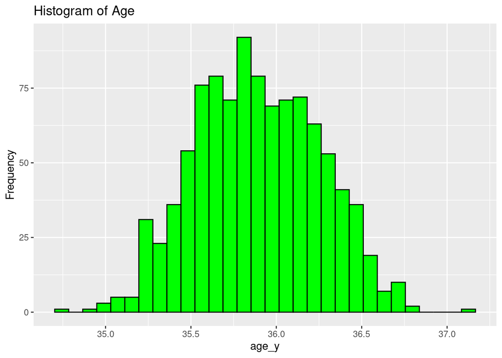

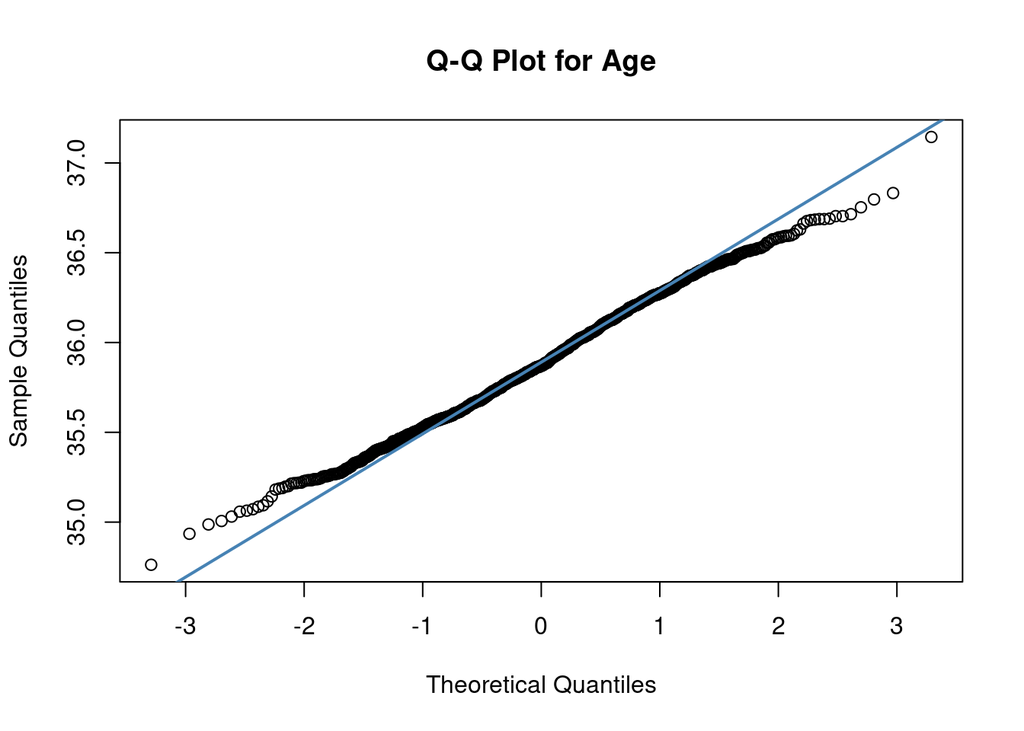

```
TRUE
TRUE    Shapiro-Wilk normality test
TRUE
TRUE data:  mds$age_y
TRUE W = 0.99564, p-value = 0.006111
```

Associations Between Participant Characteristics and Malaria Infection

| label | Total N | Missing N | levels | Yes | No | p |
| --- | --- | --- | --- | --- | --- | --- |
| Total N |  |  |  | 374 | 626 |  |
| sex | 1000 (100.0) | 0 | Female | 191 (51.1) | 326 (52.1) | 0.808 |
|  |  |  | Male | 183 (48.9) | 300 (47.9) |  |
|  |  |  | (Missing) | 0 | 0 |  |
| bmi | 1000 (100.0) | 0 | Mean (SD) | 27.1 (4.6) | 26.4 (4.6) | 0.023 |
| age_y | 1000 (100.0) | 0 | Mean (SD) | 35.9 (0.4) | 35.9 (0.4) | 0.195 |
| bednet | 1000 (100.0) | 0 | Never | 149 (39.8) | 176 (28.1) | 0.001 |
|  |  |  | Sometimes | 115 (30.7) | 219 (35.0) |  |
|  |  |  | Always | 110 (29.4) | 231 (36.9) |  |
|  |  |  | (Missing) | 0 | 0 |  |

### Summary of the Insights from the Output

- **Total Participants**: 1000
  - **Malaria**: 374
  - **No Malaria**: 626
- **Sex**
  - No significant difference in malaria infection rates between males and females.
  - p-value: 0.808
- **BMI**
  - Participants with malaria have a significantly higher average BMI (27.1) compared to those without (26.4).
  - p-value: 0.023
- **Age**
  - Average age is similar for both groups, around 35.9 years.
  - p-value: 0.195
- **Bed Net Usage**
  - Significant differences in malaria infection rates based on bed net usage:
    - **Never**: 39.8% with malaria vs. 28.1% without (p = 0.001)
    - **Sometimes** and **Always** users show lower infection rates, suggesting protective effects.

### Conclusion

BMI and bed net usage are significant factors associated with malaria infection in this study.

- **BMI**: BMI is a potential risk factor for malaria, possibly due to physiological or behavioral factors.
- **Bednet Usage**: Bednet usage is strongly associated with reduced malaria risk, emphasizing its importance in prevention strategies.
- **Sex and Age**: Sex and age do not significantly influence malaria risk in this population, suggesting interventions can be uniformly applied across these demographics.

### Exercise 5

Suppose that, for answering the main research question, we are going to used multivariate logistic regression, having the variable `had_malaria` as the dependent variable and the `treatment` as one of the independent variables. Looking at your output of Exercise 4, what other independent variable would you include in the model?

#### Exercise 5 Solution:

From the findings of Exercise 4, the other independent variables are ;

-Bednet Usage

### Reason

Bednet usage had a highly significant association with malaria incidence, with a p-value of 0.001.

-BMI

### Reasons

The output showed statistically significant association between BMI and malaria incidence, with a p-value of 0.023.

However, confirmatory analysis can be performed on all the variables to confirm its significance.